Name - Janhavee Kanoje

GH Number - GH1033705

Subject Code - M504A AI and Applications

Professor's Name - Prof. Amirhossein Jamalian

**Explanatory Data Analysis of Companies Bankrupcy Risk**

**Introduction**

**1. Business Context**

Our client is a Central European investment firm.

They have a large financial dataset that contains important indicators of the risk of a company going bankrupt. Among other important financial metrics, this dataset includes debt ratio percentage, borrowing dependency, liability-to-equity ratio, and interest coverage ratio.

The client intends to use this information to improve their risk assessment techniques and investment decision-making process when evaluating potential companies for investment.

It is my role as a data science consultant to do an Explanatory Data Analysis (EDA) in order to find notable patterns and relevant details in the dataset. This will help the company optimise its investment approach and make good data-driven decisions to minimise risks by looking at the risk indicators linked to bankruptcy.

**2. Objectives**

1. Clean and analyze the data to meet clients demand by answering the business questions.
2. EDA is performed in order to provide actionable insights which will be further used cleaning and processing the data, that will help the investment firm enhance its risk assessment strategies.

**3. Data Source**

This data set is pulled from a public source of Kaggle.com. The link to the data set is:

https://www.kaggle.com/datasets/fedesoriano/company-bankruptcy-prediction?select=data.csv

**4. Business Questions**

1. Which financial ratios are the best indicators of bankruptcy?
2. If we want to avoid bankruptcy, what are the early red signs?
3. How does a company's debt load affect how likely it is to become bankrupt?
4. When evaluating a company's danger of bankruptcy, which financial indicators should investors focus on?
5. if we want to take a frim out from bankruptcy which features should be restored back and focused on?

**Import Required Packages**

```python
import pandas as pd
import numpy as np
import matplotlib.pyplot as plt
import seaborn as sns
import plotly.express as px
import plotly.graph_objects as go
```

The original dataset had 96 columns in total, out of which many didn't contirbute effectively towards companies bankrupcy risk. So, i performed correlation matrix and random forest algorithm to check feature importance and went ahead with the features that contribute the most amongst the dataset.

**Data Exploration**

We check for null values and duplicated values in the dataset. We saw presence of null values in the dataset

```python
df = pd.read_csv("/content/Data_Bank.csv")
df.head()
```

|  | Net Income to Stockholder's Equity | Net Value Growth Rate | Borrowing dependency | Persistent EPS in the Last Four Seasons | Net Value Per Share (B) | Non-industry income and expenditure/revenue | Total income/Total expense | Interest Expense Ratio | Degree of Financial Leverage (DFL) | Equity to Liability | ... | Total debt/Total net worth | Interest-bearing debt interest rate | Inventory/Working Capital | Cash/Total Assets | Current Liabilities/Equity | Retained Earnings to Total Assets | Debt ratio % | Working Capital/Equity | ROA(C) before interest and depreciation before interest | Bankrupt? |
| --- | --- | --- | --- | --- | --- | --- | --- | --- | --- | --- | --- | --- | --- | --- | --- | --- | --- | --- | --- | --- | --- |
| 0 | 0.827890 | 0.000327 | 0.390284 | 0.169141 | 0.147950 | 0.302646 | 0.002022 | 0.629951 | 0.026601 | 0.016469 | ... | 0.021266 | 0.000725 | 0.276920 | 0.004094 | 0.339077 | 0.903225 | 0.207576 | 0.721275 | 0.370594 | 1 |
| 1 | 0.839969 | 0.000443 | 0.376760 | 0.208944 | 0.182251 | 0.303556 | 0.002226 | 0.635172 | 0.264577 | 0.020794 | ... | 0.012502 | 0.000647 | 0.289642 | 0.014948 | 0.329740 | 0.931065 | 0.171176 | 0.731975 | 0.464291 | 1 |
| 2 | 0.836774 | 0.000396 | 0.379093 | 0.180581 | 0.177911 | 0.302035 | 0.002060 | 0.629631 | 0.026555 | 0.016474 | ... | 0.021248 | 0.000790 | 0.277456 | 0.000991 | 0.334777 | 0.909903 | 0.207516 | 0.742729 | 0.426071 | 1 |
| 3 | 0.834697 | 0.000382 | 0.379743 | 0.193722 | 0.154187 | 0.303350 | 0.001831 | 0.630228 | 0.026697 | 0.023982 | ... | 0.009572 | 0.000449 | 0.276580 | 0.018851 | 0.331509 | 0.906902 | 0.151465 | 0.729825 | 0.399844 | 1 |
| 4 | 0.839973 | 0.000439 | 0.375025 | 0.212537 | 0.167502 | 0.303475 | 0.002224 | 0.636055 | 0.024752 | 0.035490 | ... | 0.005150 | 0.000686 | 0.287913 | 0.014161 | 0.330726 | 0.913850 | 0.106509 | 0.732000 | 0.465022 | 1 |

5 rows × 21 columns

```python
print(df.shape)
```

```
(6819, 21)
```

**Data Cleaning**

There are total of 20 features and 1 target feature in the dataset and all of them are numerical features. Also there are null values present in the dataset, so we replaced them with specific average values.

```python
print(df.shape)
df.dtypes
df.isna().sum()
```

```
(6819, 21)
```

|  | 0 |
| --- | --- |
| Net Income to Stockholder's Equity | 19 |
| Net Value Growth Rate | 21 |
| Borrowing dependency | 22 |
| Persistent EPS in the Last Four Seasons | 21 |
| Net Value Per Share (B) | 18 |
| Non-industry income and expenditure/revenue | 23 |
| Total income/Total expense | 15 |
| Interest Expense Ratio | 21 |
| Degree of Financial Leverage (DFL) | 30 |
| Equity to Liability | 28 |
| Interest Coverage Ratio (Interest expense to EBIT) | 20 |
| Total debt/Total net worth | 23 |
| Interest-bearing debt interest rate | 19 |
| Inventory/Working Capital | 21 |
| Cash/Total Assets | 15 |
| Current Liabilities/Equity | 25 |
| Retained Earnings to Total Assets | 19 |
| Debt ratio % | 18 |
| Working Capital/Equity | 30 |
| ROA(C) before interest and depreciation before interest | 18 |
| Bankrupt? | 0 |

**dtype:** int64

we have individually analysed the features type and replaced the null values of the specific features with its consecutive best fit.

1. where there is normally distributed numerical data, Mean is used.
2. Where data is more frequent, and cluster formation is possible, mode is used.
3. Where data consist of skewed numerical data due to extreme high/low values, median is used.

```python
df = df.copy(deep=True)


df[" Net Income to Stockholder's Equity"] = df[" Net Income to Stockholder's Equity"].fillna(df[" Net Income to Stockholder's Equity"].mean())

df[" Net Value Per Share (B)"] = df[" Net Value Per Share (B)"].fillna(df[" Net Value Per Share (B)"].mean())

df[" Total income/Total expense"] = df[" Total income/Total expense"].fillna(df[" Total income/Total expense"].mean())

df[" Interest Coverage Ratio (Interest expense to EBIT)"] = df[" Interest Coverage Ratio (Interest expense to EBIT)"].fillna(df[" Interest Coverage Ratio (Interest expense to EBIT)"].mean())

df[" Interest-bearing debt interest rate"] = df[" Interest-bearing debt interest rate"].fillna(df[" Interest-bearing debt interest rate"].mean())

df[" Cash/Total Assets"] = df[" Cash/Total Assets"].fillna(df[" Cash/Total Assets"].mean())

df[" Retained Earnings to Total Assets"] = df[" Retained Earnings to Total Assets"].fillna(df[" Retained Earnings to Total Assets"].mean())

df[" ROA(C) before interest and depreciation before interest"] = df[" ROA(C) before interest and depreciation before interest"].fillna(df[" ROA(C) before interest and depreciation before interest"].mean())


df[" Working Capital/Equity"] = df[" Working Capital/Equity"].fillna(df[" Working Capital/Equity"].mode()[0])

df[" Persistent EPS in the Last Four Seasons"] = df[" Persistent EPS in the Last Four Seasons"].fillna(df[" Persistent EPS in the Last Four Seasons"].mode()[0])

df[" Degree of Financial Leverage (DFL)"] = df[" Degree of Financial Leverage (DFL)"].fillna(df[" Degree of Financial Leverage (DFL)"].mode()[0])


df[" Net Value Growth Rate"] = df[" Net Value Growth Rate"].fillna(df[" Net Value Growth Rate"].median())

df[" Borrowing dependency"] = df[" Borrowing dependency"].fillna(df[" Borrowing dependency"].median())

df[" Non-industry income and expenditure/revenue"] = df[" Non-industry income and expenditure/revenue"].fillna(df[" Non-industry income and expenditure/revenue"].median())

df[" Interest Expense Ratio"] = df[" Interest Expense Ratio"].fillna(df[" Interest Expense Ratio"].median())

df[" Equity to Liability"] = df[" Equity to Liability"].fillna(df[" Equity to Liability"].median())

df[" Total debt/Total net worth"] = df[" Total debt/Total net worth"].fillna(df[" Total debt/Total net worth"].median())

df[" Inventory/Working Capital"] = df[" Inventory/Working Capital"].fillna(df[" Inventory/Working Capital"].median())

df[" Current Liabilities/Equity"] = df[" Current Liabilities/Equity"].fillna(df[" Current Liabilities/Equity"].median())

df[" Debt ratio %"] = df[" Debt ratio %"].fillna(df[" Debt ratio %"].median())
```

```python
print(df.shape)
df.isna().sum()
```

```
(6819, 21)
```

|  | 0 |
| --- | --- |
| Net Income to Stockholder's Equity | 0 |
| Net Value Growth Rate | 0 |
| Borrowing dependency | 0 |
| Persistent EPS in the Last Four Seasons | 0 |
| Net Value Per Share (B) | 0 |
| Non-industry income and expenditure/revenue | 0 |
| Total income/Total expense | 0 |
| Interest Expense Ratio | 0 |
| Degree of Financial Leverage (DFL) | 0 |
| Equity to Liability | 0 |
| Interest Coverage Ratio (Interest expense to EBIT) | 0 |
| Total debt/Total net worth | 0 |
| Interest-bearing debt interest rate | 0 |
| Inventory/Working Capital | 0 |
| Cash/Total Assets | 0 |
| Current Liabilities/Equity | 0 |
| Retained Earnings to Total Assets | 0 |
| Debt ratio % | 0 |
| Working Capital/Equity | 0 |
| ROA(C) before interest and depreciation before interest | 0 |
| Bankrupt? | 0 |

**dtype:** int64

```python
df.duplicated().values.any()
```

```
np.False_
```

Till now it is clear that:

1. The dataset no longer has any null values and duplicate values.
2. This dataset contains all numerical attirbutes and no categorical attributes.

```python
df.head(5)
```

|  | Net Income to Stockholder's Equity | Net Value Growth Rate | Borrowing dependency | Persistent EPS in the Last Four Seasons | Net Value Per Share (B) | Non-industry income and expenditure/revenue | Total income/Total expense | Interest Expense Ratio | Degree of Financial Leverage (DFL) | Equity to Liability | ... | Total debt/Total net worth | Interest-bearing debt interest rate | Inventory/Working Capital | Cash/Total Assets | Current Liabilities/Equity | Retained Earnings to Total Assets | Debt ratio % | Working Capital/Equity | ROA(C) before interest and depreciation before interest | Bankrupt? |
| --- | --- | --- | --- | --- | --- | --- | --- | --- | --- | --- | --- | --- | --- | --- | --- | --- | --- | --- | --- | --- | --- |
| 0 | 0.827890 | 0.000327 | 0.390284 | 0.169141 | 0.147950 | 0.302646 | 0.002022 | 0.629951 | 0.026601 | 0.016469 | ... | 0.021266 | 0.000725 | 0.276920 | 0.004094 | 0.339077 | 0.903225 | 0.207576 | 0.721275 | 0.370594 | 1 |
| 1 | 0.839969 | 0.000443 | 0.376760 | 0.208944 | 0.182251 | 0.303556 | 0.002226 | 0.635172 | 0.264577 | 0.020794 | ... | 0.012502 | 0.000647 | 0.289642 | 0.014948 | 0.329740 | 0.931065 | 0.171176 | 0.731975 | 0.464291 | 1 |
| 2 | 0.836774 | 0.000396 | 0.379093 | 0.180581 | 0.177911 | 0.302035 | 0.002060 | 0.629631 | 0.026555 | 0.016474 | ... | 0.021248 | 0.000790 | 0.277456 | 0.000991 | 0.334777 | 0.909903 | 0.207516 | 0.742729 | 0.426071 | 1 |
| 3 | 0.834697 | 0.000382 | 0.379743 | 0.193722 | 0.154187 | 0.303350 | 0.001831 | 0.630228 | 0.026697 | 0.023982 | ... | 0.009572 | 0.000449 | 0.276580 | 0.018851 | 0.331509 | 0.906902 | 0.151465 | 0.729825 | 0.399844 | 1 |
| 4 | 0.839973 | 0.000439 | 0.375025 | 0.212537 | 0.167502 | 0.303475 | 0.002224 | 0.636055 | 0.024752 | 0.035490 | ... | 0.005150 | 0.000686 | 0.287913 | 0.014161 | 0.330726 | 0.913850 | 0.106509 | 0.732000 | 0.465022 | 1 |

5 rows × 21 columns

**Data Analysis**

We will further analyse the data by visualizing specific features in order to answer the buisness questions.

As we can see approximately 97% of the target label are not bankrupt whereas only 3% are bankrupt.

```
Bankrupt?
0    0.967737
1    0.032263
Name: proportion, dtype: float64
```

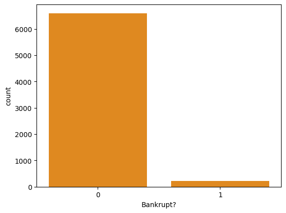

```python
target_column = 'Bankrupt?'
target_distribution = df[target_column].value_counts(normalize=True)
print(target_distribution)
sns.barplot(df["Bankrupt?"].value_counts(), color="#FF8C00")
```

The matrix gives a broader view of the correlation between the features.

**High-positive corelation:**

Higher Net Value Per Share (B) indicates companies financial stability which gives higher Persistent EPS in the Last Four Seasons.

Borrowing depency is directly related to Current Liabilities/Equity which says, companies with lower borrowing depency will have lower liability/equity and hence wont go bankrupt

Companies with higher Retained Earnings to Total Assets also have higher ROA(C) before interest and depreciation. Persistent EPS in the Last Four Seasons is also directly proportional to ROA(C) before interest and depreciation.

Higher working capital positively increases net income of the company.

**High-Negative corelation:**

Companies with higher borrowing depency have lower working capital and lower net income to stockholder's equilty. Similarly, companies with higher liability/equity has lower working capital and lower net income to stockholder's equilty.

Companies with higher equity-to-liability ratio has lower debt ratio. That shows they have more equity relative to liabilities.

**Moderate corelation:**

Low debt ratio indicates company might also have a low borrowing dependency. Higher retained earnings indicates higher EPS as earnings can be used to reinvest within the company resulting in increased EPS.

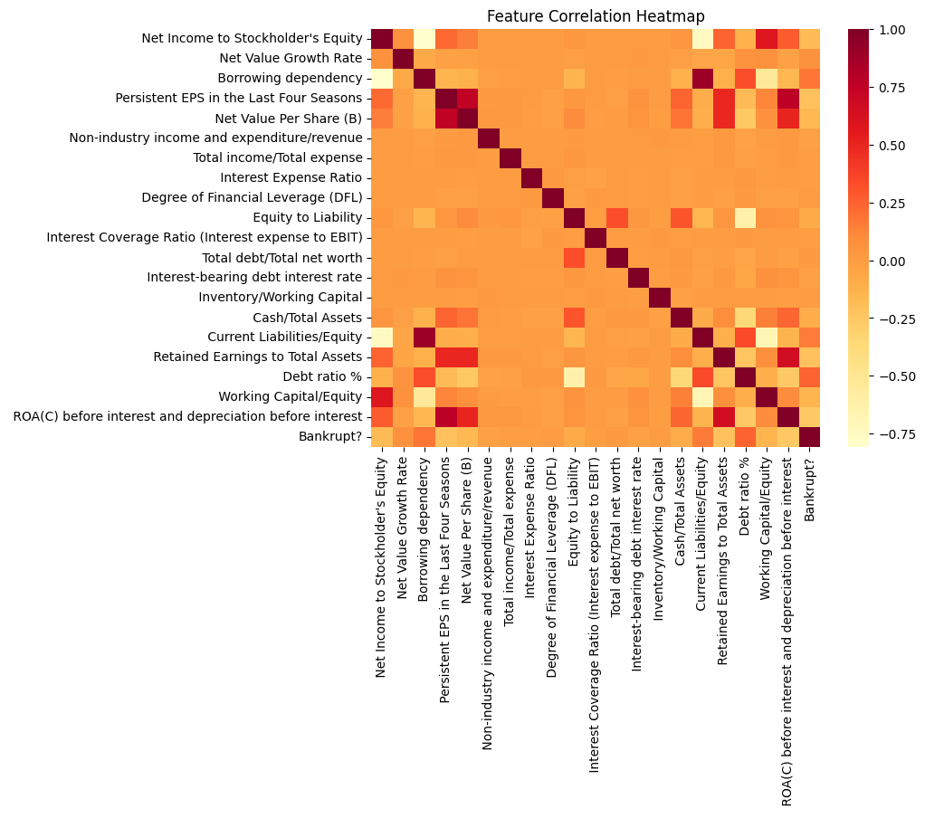

```python
correlation_matrix = df.corr()

target_corr = correlation_matrix["Bankrupt?"].sort_values(ascending=False)
plt.figure(figsize=(8, 6))
sns.heatmap(correlation_matrix, cmap="YlOrRd", annot=False)
plt.title("Feature Correlation Heatmap")
plt.show()
```

1. Which financial ratios are the best indicators of bankruptcy?

A corporation is at risk of financial trouble when its debt ratio is higher (orange) and its shift towards right shows the firm is more dependent on debt finances, which is an indication of financial instability.

A low ROA (orange)indicates inadequate use of assets, which lowers returns profitability and raises the risk of bankruptcy.

Net income to stockholders equity which, if is lower and varying as shown in the chart(orange area), shows that the company is not making enough profit and is at risk. similarly, if current liabilities are more, it reflects chances of going under debt which may result in bankruptcy.

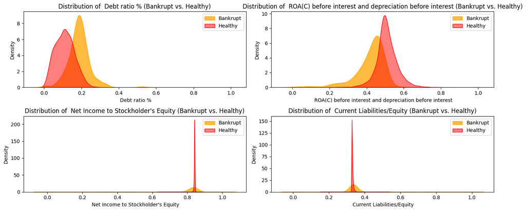

```python
features = [" Debt ratio %"," ROA(C) before interest and depreciation before interest", " Net Income to Stockholder's Equity"," Current Liabilities/Equity"]

df_bankrupt, df_healthy = df[df["Bankrupt?"] == 1], df[df["Bankrupt?"] == 0]

fig, axes = plt.subplots(2, 2, figsize=(14, 6))
for i, feature in enumerate(features):
    row = i // 2
    col = i % 2
    ax = axes[row, col]
    sns.kdeplot(df_bankrupt[feature], label="Bankrupt", fill=True, color="orange", alpha=0.75, ax=ax)
    sns.kdeplot(df_healthy[feature], label="Healthy", fill=True, color="red", alpha=0.5, ax=ax)
    ax.set_title(f"Distribution of {feature} (Bankrupt vs. Healthy)")
    ax.legend()

plt.tight_layout()
plt.show()
```

2. If we want to avoid bankruptcy, what are the early red signs?

A declining and narrow EPS (orange)indicates weak profitability, making it harder for a company to sustain. It may act as one of the initial sign(along with debt ration and liabilities)as companys profit has not been meet from past four seasons.

A concentrated peak in chart (orange) shows Lower cash/assets ratio indicating less liquidity in the firm and inability to cover liabilities, making financial downturns more difficult to manage.

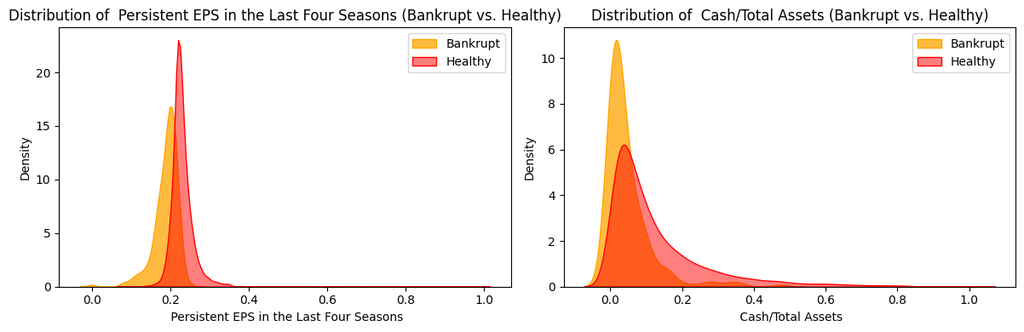

```python
features = [" Persistent EPS in the Last Four Seasons",  " Cash/Total Assets"]

df_bankrupt, df_healthy = df[df["Bankrupt?"] == 1], df[df["Bankrupt?"] == 0]

fig, axes = plt.subplots(1, 2, figsize=(12, 4))
for ax, feature in zip(axes, features):
    sns.kdeplot(df_bankrupt[feature], label="Bankrupt", fill=True, color="orange", alpha=0.75, ax=ax)
    sns.kdeplot(df_healthy[feature], label="Healthy", fill=True, color="red", alpha=0.5, ax=ax)
    ax.set_title(f"Distribution of {feature} (Bankrupt vs. Healthy)")
    ax.legend()

plt.tight_layout()
plt.show()
```

3. How does a company's debt load affect how likely it is to become bankrupt?

Company's debt and borrowing pattern plays an crucial role in predicting the risk of bankruptcy, based on which investors will not willingly invest in the firms resulting in inability to repay the debts.

As discussed in 1st question, Excessive strain is indicated by a greater debt ratio, which raises the danger of bankruptcy.

For total debt/net worth the chart shows very identical spike around 0, but bankrupt firms(orange) have a broder spread indicating variance, increasing their risk.

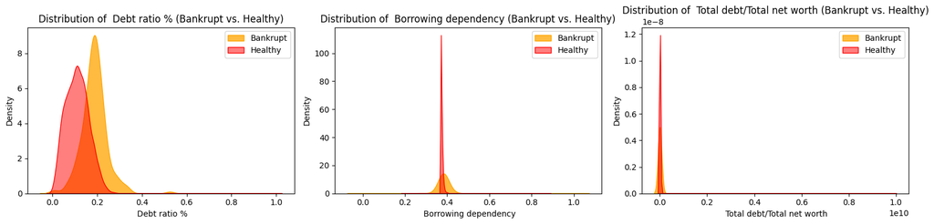

```python
features = [" Debt ratio %", " Borrowing dependency", " Total debt/Total net worth"]
df_bankrupt, df_healthy = df[df["Bankrupt?"] == 1], df[df["Bankrupt?"] == 0]

fig, axes = plt.subplots(1, 3, figsize=(16, 4))
for ax, feature in zip(axes, features):
    sns.kdeplot(df_bankrupt[feature], label="Bankrupt", fill=True, color="orange", alpha=0.75, ax=ax)
    sns.kdeplot(df_healthy[feature], label="Healthy", fill=True, color="red", alpha=0.5, ax=ax)
    ax.set_title(f"Distribution of {feature} (Bankrupt vs. Healthy)")
    ax.legend()

plt.tight_layout()
plt.show()
```

4. When evaluating a company's danger of bankruptcy, which financial indicators should investors focus on?

As a investor, there are many factors including debt ratio, current liabailities, ROA, etc. But as investors would primarily focus on how can the firm manage to make most of their investment. so, below factors can be primary features.

Firms with higher retained earnings relative to total assets have lower chances to go bankrupt.As shown in chart(red), a significant peak around 1 states that firm retained a noticable portion of the earnings linked to their assets. Businesses with more retained earnings should be given priority by investors since they are more resilient and financially stable.

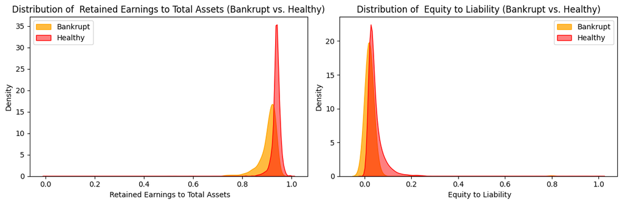

```python
features = [" Retained Earnings to Total Assets", " Equity to Liability"]
df_bankrupt, df_healthy = df[df["Bankrupt?"] == 1], df[df["Bankrupt?"] == 0]

fig, axes = plt.subplots(1, 2, figsize=(12, 4))
for ax, feature in zip(axes, features):
    sns.kdeplot(df_bankrupt[feature], label="Bankrupt", fill=True, color="orange", alpha=0.75, ax=ax)
    sns.kdeplot(df_healthy[feature], label="Healthy", fill=True, color="red", alpha=0.5, ax=ax)
    ax.set_title(f"Distribution of {feature} (Bankrupt vs. Healthy)")
    ax.legend()

plt.tight_layout()
plt.show()
```

5. If we want to take a frim out from bankruptcy which features should be restored back or focused on?

This can result in reduced debt ratio and increased working capital/equity, this capital should be balanced correctly and bankruptcy can be demolished by doing so.

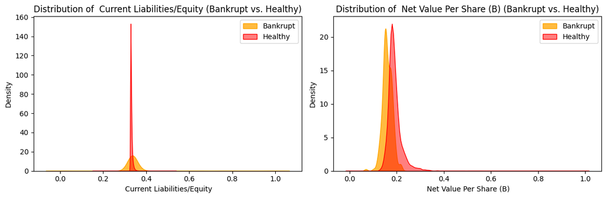

```python
features = [" Current Liabilities/Equity", " Net Value Per Share (B)"]
df_bankrupt, df_healthy = df[df["Bankrupt?"] == 1], df[df["Bankrupt?"] == 0]

fig, axes = plt.subplots(1, 2, figsize=(12, 4))
for ax, feature in zip(axes, features):

       sns.kdeplot(df_bankrupt[feature], label="Bankrupt", fill=True, color="orange", alpha=0.75,ax=ax)
       sns.kdeplot(df_healthy[feature], label="Healthy", fill=True, color="red", alpha=0.5, ax=ax)
       ax.set_title(f"Distribution of {feature} (Bankrupt vs. Healthy)")
       ax.legend()
plt.tight_layout()
plt.show()
```

**Conclusion**

1. Data provided was not cleaned as it had many null values and noise in it.
2. To many irrelevant features were present making it difficult to process.
3. Data should have contained various industries related data as well to attain more deeper analysis.
4. Borrowing dependency, current liability/equity, Debt ratio act as clear signs for banckruptcy.
5. ROA(c), equity to liability, Retained earnings, working capital plays crucial role to avoid bankruptcy by controling liquidity.To improve financial health, concentrate on raising ROA, EPS, and retained earnings.
6. Solutions:
- To detect the above-mentioned early signs, firms should keep track and monitor these aspects at regular intervals.
- In case it is too late to notice the early signs, firms should be ready with a recovery plan to avoid complete bankruptcy.In order to turn a profit again, struggling businesses should restructure their debt, cut inefficient expenditures, and optimize their operations.